# GSB544 Lab 8: Cannabis Types

Author

Joseph Lee

Published

December 4, 2023

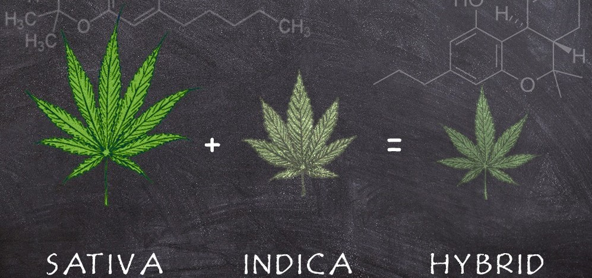

```python
import pandas as pd

weed = pd.read_csv("https://www.dropbox.com/s/s2a1uoiegitupjc/cannabis_full.csv?raw=1")
weed
```

|  | Strain | Type | Rating | Effects | Flavor | Creative | Energetic | Tingly | Euphoric | Relaxed | ... | Ammonia | Minty | Tree | Fruit | Butter | Pineapple | Tar | Rose | Plum | Pear |
| --- | --- | --- | --- | --- | --- | --- | --- | --- | --- | --- | --- | --- | --- | --- | --- | --- | --- | --- | --- | --- | --- |
| 0 | 100-Og | hybrid | 4.0 | Creative,Energetic,Tingly,Euphoric,Relaxed | Earthy,Sweet,Citrus | 1.0 | 1.0 | 1.0 | 1.0 | 1.0 | ... | 0.0 | 0.0 | 0.0 | 0.0 | 0.0 | 0.0 | 0.0 | 0.0 | 0.0 | 0.0 |
| 1 | 98-White-Widow | hybrid | 4.7 | Relaxed,Aroused,Creative,Happy,Energetic | Flowery,Violet,Diesel | 1.0 | 1.0 | 0.0 | 0.0 | 1.0 | ... | 0.0 | 0.0 | 0.0 | 0.0 | 0.0 | 0.0 | 0.0 | 0.0 | 0.0 | 0.0 |
| 2 | 1024 | sativa | 4.4 | Uplifted,Happy,Relaxed,Energetic,Creative | Spicy/Herbal,Sage,Woody | 1.0 | 1.0 | 0.0 | 0.0 | 1.0 | ... | 0.0 | 0.0 | 0.0 | 0.0 | 0.0 | 0.0 | 0.0 | 0.0 | 0.0 | 0.0 |
| 3 | 13-Dawgs | hybrid | 4.2 | Tingly,Creative,Hungry,Relaxed,Uplifted | Apricot,Citrus,Grapefruit | 1.0 | 0.0 | 1.0 | 0.0 | 1.0 | ... | 0.0 | 0.0 | 0.0 | 0.0 | 0.0 | 0.0 | 0.0 | 0.0 | 0.0 | 0.0 |
| 4 | 24K-Gold | hybrid | 4.6 | Happy,Relaxed,Euphoric,Uplifted,Talkative | Citrus,Earthy,Orange | 0.0 | 0.0 | 0.0 | 1.0 | 1.0 | ... | 0.0 | 0.0 | 0.0 | 0.0 | 0.0 | 0.0 | 0.0 | 0.0 | 0.0 | 0.0 |
| ... | ... | ... | ... | ... | ... | ... | ... | ... | ... | ... | ... | ... | ... | ... | ... | ... | ... | ... | ... | ... | ... |
| 2346 | Zeus-Og | hybrid | 4.7 | Happy,Uplifted,Relaxed,Euphoric,Energetic | Earthy,Woody,Pine | 0.0 | 1.0 | 0.0 | 1.0 | 1.0 | ... | 0.0 | 0.0 | 0.0 | 0.0 | 0.0 | 0.0 | 0.0 | 0.0 | 0.0 | 0.0 |
| 2347 | Zkittlez | indica | 4.6 | Relaxed,Happy,Euphoric,Uplifted,Sleepy | Sweet,Berry,Grape | 0.0 | 0.0 | 0.0 | 1.0 | 1.0 | ... | 0.0 | 0.0 | 0.0 | 0.0 | 0.0 | 0.0 | 0.0 | 0.0 | 0.0 | 0.0 |
| 2348 | Zombie-Kush | indica | 5.0 | Relaxed,Sleepy,Talkative,Euphoric,Happy | Earthy,Sweet,Spicy/Herbal | 0.0 | 0.0 | 0.0 | 1.0 | 1.0 | ... | 0.0 | 0.0 | 0.0 | 0.0 | 0.0 | 0.0 | 0.0 | 0.0 | 0.0 | 0.0 |
| 2349 | Zombie-Og | indica | 4.4 | Relaxed,Sleepy,Euphoric,Happy,Hungry | Sweet,Earthy,Pungent | 0.0 | 0.0 | 0.0 | 1.0 | 1.0 | ... | 0.0 | 0.0 | 0.0 | 0.0 | 0.0 | 0.0 | 0.0 | 0.0 | 0.0 | 0.0 |
| 2350 | Zoom-Pie | indica | 4.6 | Hungry,Relaxed,Uplifted,Happy,Sleepy | Berry,Earthy,Pungent | 0.0 | 0.0 | 0.0 | 0.0 | 1.0 | ... | 0.0 | 0.0 | 0.0 | 0.0 | 0.0 | 0.0 | 0.0 | 0.0 | 0.0 | 0.0 |

2351 rows × 69 columns

```python
# Checking to see each variable that was created
weed.columns
```

```
Index(['Strain', 'Type', 'Rating', 'Effects', 'Flavor', 'Creative',
       'Energetic', 'Tingly', 'Euphoric', 'Relaxed', 'Aroused', 'Happy',
       'Uplifted', 'Hungry', 'Talkative', 'Giggly', 'Focused', 'Sleepy', 'Dry',
       'Mouth', 'Earthy', 'Sweet', 'Citrus', 'Flowery', 'Violet', 'Diesel',
       'Spicy/Herbal', 'Sage', 'Woody', 'Apricot', 'Grapefruit', 'Orange',
       'Pungent', 'Grape', 'Pine', 'Skunk', 'Berry', 'Pepper', 'Menthol',
       'Blue', 'Cheese', 'Chemical', 'Mango', 'Lemon', 'Peach', 'Vanilla',
       'Nutty', 'Chestnut', 'Tea', 'Tobacco', 'Tropical', 'Strawberry',
       'Blueberry', 'Mint', 'Apple', 'Honey', 'Lavender', 'Lime', 'Coffee',
       'Ammonia', 'Minty', 'Tree', 'Fruit', 'Butter', 'Pineapple', 'Tar',
       'Rose', 'Plum', 'Pear'],
      dtype='object')
```

```python
# Checking for unique values of 'Type'
weed['Type'].unique()
```

```
array(['hybrid', 'sativa', 'indica'], dtype=object)
```

# **Part One: Binary Classification**

Create a dataset that is limited only to the ‘Sativa’ and ‘Indica’ type cannabis strains.

This section asks you to create a final best model for each of the four new model types studied this week: LDA, QDA, SVC, and SVM. For SVM, you may limit yourself to only the polynomial kernel.

For each, you should:

Choose a metric you will use to select your model, and briefly justify your choice. (Hint: There is no specific target category here, so this should not be a metric that only prioritizes one category.)

Find the best model for predicting the Type variable. Don’t forget to tune any hyperparameters.

Report the (cross-validated!) metric.

Fit the final model.

Output a confusion matrix.

```python
# Creating a new dataset that is limited only to Sative and Indica (nh = no hybrid)
nh_weed = weed[weed['Type'].isin(['sativa', 'indica'])]
nh_weed = nh_weed.drop(['Effects', 'Flavor'], axis=1)
nh_weed.set_index('Strain', inplace=True)
```

```python
# Checking for NA values
nh_weed.isna().sum()
```

```
Type          0
Rating        0
Creative     17
Energetic    16
Tingly       17
             ..
Pineapple    21
Tar          21
Rose         21
Plum         21
Pear         21
Length: 66, dtype: int64
```

*After checking what values were actually NA, it was found that when the ‘Effects’ or ‘Flavor’ column had a value of NA, the corresponding dummy variables all had NA for their values. This essentially means that NA = 0, therefore all NA values will be converted to 0.*

```python
# Replacing NA values with 0
nh_weed.fillna(0, inplace=True)
```

```python
# Checking the counts of the response variable values
nh_weed['Type'].value_counts()
```

```
indica    699
sativa    440
Name: Type, dtype: int64
```

*There is an imbalance in the counts of *Indica* and *Sativa*.*

```python
from sklearn.model_selection import train_test_split, cross_val_score
from sklearn.metrics import confusion_matrix, f1_score

# Defining the response and predictor variables
X = nh_weed.drop('Type', axis=1)
y = nh_weed['Type']

# Splitting the data into training and test sets
X_train, X_test, y_train, y_test = train_test_split(X, y, test_size=0.25, random_state=42, stratify=y)
```

*Q1: LDA*

*Because there is an imbalance in the counts of each type of marijuana, ‘Indica’ or ‘Sativa’, F1-score will be used, instead of accuracy, for the scoring metric. This will ensure that both **FP** and **FN** will be taken into account. In addition, the training and test sets were stratified to ensure equal proportions of both.*

```python
from sklearn.discriminant_analysis import LinearDiscriminantAnalysis

# Initializing the LDA model and fitting on the training set
lda = LinearDiscriminantAnalysis()
lda.fit(X_train, y_train)

# Evaluating the model based on F1 metrics
f1_scores1 = cross_val_score(lda, X_train, y_train, cv=5, scoring='f1_macro')
print(f"Cross-validated LDA F1-score: {f1_scores1.mean()}")
```

```
Cross-validated LDA F1-score: 0.8296970048488299
```

- The *LDA* model had an *F1-score* of **82.97%**, which indicates that the model is performing well on the training data. There is a strong balance between precision and recall across the cross-validation folds.

```python
# Fitting and predicting on the full modified dataset
lda_full = LinearDiscriminantAnalysis()
lda_full.fit(X, y)
y_pred_lda = lda_full.predict(X)

# LDA Confusion Matrix using the full modified dataset
conf_matrix_lda = confusion_matrix(y, y_pred_lda)
print(f"Full Model Confusion Matrix LDA: \n{conf_matrix_lda}")
```

```
Full Model Confusion Matrix LDA:
[[638  61]
 [ 88 352]]
```

- True Positives (**TP**) - The model correctly identified **638** instances as their actual class.
- False Positives (**FP**) - The model incorrectly predicted **61** instances as positive that are actually negative.
- False Negatives (**FN**) - The model incorrectly predicted **88** instances as negative that are actually positive.
- True Negatives (**TN**) - The model correctly identified **352** instances as their actual class.
- There are a significantly higher number of true positives and true negatives than false positives and false negatives, which indicates good model performance.

*Q2: QDA*

```python
from sklearn.discriminant_analysis import QuadraticDiscriminantAnalysis
from sklearn.model_selection import GridSearchCV

# Defining the QDA hyperparameter grid
param_grid_qda = {
    'reg_param': [0, 0.1, 0.2, 0.3, 0.4, 0.5, 0.6, 0.7, 0.8, 0.9, 1]
}
```

```python
# Initializing GridSearchCV and fitting on the training data
grid_search_qda = GridSearchCV(QuadraticDiscriminantAnalysis(), param_grid_qda, n_jobs=-1, cv=5, scoring='f1_macro')
grid_search_qda.fit(X_train, y_train)

# Printing out the best QDA parameters and cross-validated F1 scores
print(f"Best Parameters QDA: {grid_search_qda.best_params_}")
print(f"Best Cross-Validated QDA F1-score: {grid_search_qda.best_score_}")
```

```
Best Parameters QDA: {'reg_param': 0.1}
Best Cross-Validated QDA F1-score: 0.8366767722779258
```

- The *regularization parameter* of **0.1** for the *QDA* model was chosen and this dealt with the issue of multicollinearity.
- The *QDA* model had an *F1-score* of **83.67%**, which indicates that this model performed slightly better than the *LDA* model on the training set data.

```python
# Fitting and predicting on the full modified dataset
best_qda = grid_search_qda.best_estimator_
best_qda.fit(X, y)
y_pred_qda = best_qda.predict(X)

# QDA Confusion Matrix using the full modified dataset
conf_matrix_qda = confusion_matrix(y, y_pred_qda)
print(f"Test Set Confusion Matrix QDA: \n{conf_matrix_qda}")
```

```
Test Set Confusion Matrix QDA:
[[631  68]
 [ 66 374]]
```

- True Positives (**TP**) - The model correctly identified **631** instances as their actual class.
- False Positives (**FP**) - The model incorrectly predicted **68** instances as positive that are actually negative.
- False Negatives (**FN**) - The model incorrectly predicted **66** instances as negative that are actually positive.
- True Negatives (**TN**) - The model correctly identified **374** instances as their actual class.
- There are a significantly higher number of true positives and true negatives than false positives and false negatives, which indicates good model performance.

*Q3: SVC*

```python
from sklearn.model_selection import GridSearchCV
from sklearn.svm import SVC

# Defining the SVC hyperparameter grid
param_grid = {
    'C': [0.1, 1, 10, 100],
    'gamma': [1, 0.1, 0.01, 0.001],
    'kernel': ['rbf', 'poly', 'sigmoid']
}
```

```python
# Initializing GridSearchCV and fitting on the training data
grid_search_svc = GridSearchCV(SVC(), param_grid, refit=True, n_jobs=-1, verbose=3, cv=5, scoring='f1_macro')
grid_search_svc.fit(X_train, y_train)

# Printing out the best SVC parameters and cross-validated F1 scores
print(f"Best Parameters SVC: {grid_search_svc.best_params_}")
print(f"Best Cross-Validated F1-score SVC: {grid_search_svc.best_score_}")
```

```
Fitting 5 folds for each of 48 candidates, totalling 240 fits
Best Parameters SVC: {'C': 100, 'gamma': 0.01, 'kernel': 'sigmoid'}
Best Cross-Validated F1-score SVC: 0.840895364658215
```

- The *regularization parameter* of **C=100** for the *SVC* model was chosen and this indicates that our dataset benefits from a more complex model.
- The *gamma* value of **0.01** for the *kernel* **sigmoid** was chosen and this indicates that this *kernel* and *gamma* value performed the best in shaping the decision boudary.
- The *SVC* model had an *F1-score* of **84.09%**, which indicates that this model performed better than the *QDA* and the *LDA* model.

```python
# Fitting and predicting on the full modified dataset
best_svc = grid_search_svc.best_estimator_
best_svc.fit(X, y)
y_pred_svc = best_svc.predict(X)

# SVC Confusion Matrix using the full modified dataset
conf_matrix_svc = confusion_matrix(y, y_pred_svc)
print(f"Test Set Confusion Matrix SVC: \n{conf_matrix_svc}")
```

```
Test Set Confusion Matrix SVC:
[[618  81]
 [ 82 358]]
```

- True Positives (**TP**) - The model correctly identified **618** instances as their actual class.
- False Positives (**FP**) - The model incorrectly predicted **81** instances as positive that are actually negative.
- False Negatives (**FN**) - The model incorrectly predicted **82** instances as negative that are actually positive.
- True Negatives (**TN**) - The model correctly identified **358** instances as their actual class.
- There are a significantly higher number of true positives and true negatives than false positives and false negatives, which indicates good model performance.

*Q4: SVM*

```python
# Defining the SVM hyperparameter grid
param_grid = {
    'C': [0.1, 1, 10, 100],
    'gamma': [0.001, 0.01, 0.1, 1],
    'degree': [2, 3, 4],  # Example degrees for polynomial kernel
    'coef0': [0, 1],  # Example constant terms
    'kernel': ['poly']  # Polynomial kernel
}
```

```python
# Initializing GridSearchCV and fitting on the training data
grid_search_svm = GridSearchCV(SVC(), param_grid, refit=True, n_jobs=-1, verbose=3, cv=5, scoring='f1_macro')
grid_search_svm.fit(X_train, y_train)

# Printing out the best SVM parameters and cross-validated F1 scores
print(f"Best Parameters SVM: {grid_search_svm.best_params_}")
print(f"Best Cross-Validated F1-score SVM: {grid_search_svm.best_score_}")
```

```
Fitting 5 folds for each of 96 candidates, totalling 480 fits
Best Parameters SVM: {'C': 100, 'coef0': 0, 'degree': 4, 'gamma': 0.01, 'kernel': 'poly'}
Best Cross-Validated F1-score SVM: 0.8430501275464017
```

- The *regularization parameter* of **C=100** for the *SVM* model was chosen and this indicates that our dataset benefits from a more complex model.
- The *coef0* value of **0** was chosen and this indicates that the independent term in the *kernel* function was not significant.
- The *degree* value of **4** indicates that the polynomial kernel of the 4th degree was the best performing.
- The *gamma* value of **0.01** for the kernel *poly* was chosen and this indicates that this *kernel* and *gamma* value performed the best in shaping the decision boudary.
- The *SVM* model had an *F1-score* of **84.31%**, which indicates that this model performed the best among the *QDA*, *LDA*, and *SVC* models.

```python
# Fitting and predicting on the full modified dataset
best_svm = grid_search_svm.best_estimator_
best_svm.fit(X, y)
y_pred_svm = best_svm.predict(X)

# SVM Confusion Matrix using the full modified dataset
conf_matrix_svm = confusion_matrix(y, y_pred_svm)
print(f"Test Set Confusion Matrix SVM: \n{conf_matrix_svm}")
```

```
Test Set Confusion Matrix SVM:
[[660  39]
 [ 97 343]]
```

```python
# Printing the F1-Scores for comparison
print(f"LDA Cross-Validated F1-score: {f1_scores1.mean()}")
print(f"QDA Cross-Validated F1-score: {grid_search_qda.best_score_}")
print(f"SVC Cross-Validated F1-score: {grid_search_svc.best_score_}")
print(f"SVM Cross-Validated F1-score: {grid_search_svm.best_score_}\n")

# Converting each confusion matrix to a flat list
conf_matrix_lda_flat = conf_matrix_lda.flatten()
conf_matrix_qda_flat = conf_matrix_qda.flatten()
conf_matrix_svc_flat = conf_matrix_svc.flatten()
conf_matrix_svm_flat = conf_matrix_svm.flatten()

# Creating a dataframe
conf_matrix_df = pd.DataFrame({
    'Binary Model': ['LDA', 'QDA', 'SVC', 'SVM'],
    'TP': [conf_matrix_lda_flat[0], conf_matrix_qda_flat[0], conf_matrix_svc_flat[0], conf_matrix_svm_flat[0]],
    'FP': [conf_matrix_lda_flat[1], conf_matrix_qda_flat[1], conf_matrix_svc_flat[1], conf_matrix_svm_flat[1]],
    'FN': [conf_matrix_lda_flat[2], conf_matrix_qda_flat[2], conf_matrix_svc_flat[2], conf_matrix_svm_flat[2]],
    'TN': [conf_matrix_lda_flat[3], conf_matrix_qda_flat[3], conf_matrix_svc_flat[3], conf_matrix_svm_flat[3]]
})

print(conf_matrix_df)
```

[output not shown]

- All 4 models had robust F1-Scores, but the *SVM* model had the highest score of **84.31%**.
- The *SVM* the highest number of true positives, and the lowest number of false positives, which indicates its effectiveness in identifying positive cases and minimizing cases that are incorrectly predicted.
- The *LDA* and *QDA* models offer a more balanced performance between **TP** and **FN**.

# **Part Two: Natural Multiclass**

Now use the full dataset, including the ‘Hybrid’ strains.

```python
# Importing the dataset
weed = pd.read_csv("https://www.dropbox.com/s/s2a1uoiegitupjc/cannabis_full.csv?raw=1")

# Checking the counts of the response variable values in the full dataset
weed['Type'].value_counts()
```

```
hybrid    1212
indica     699
sativa     440
Name: Type, dtype: int64
```

*There is an imbalance in the multiclass response variable.*

```python
# Removing the 'Effects' and 'Flavor' variables because they are already dummified
weed = weed.drop(['Effects', 'Flavor'], axis=1)
weed.set_index('Strain', inplace=True)

# Replacing NA values with 0
weed.fillna(0, inplace=True)
```

```python
# Defining the response and predictor variables
X1 = weed.drop('Type', axis=1)
y1 = weed['Type']

# Splitting the data into training and test sets
X_train, X_test, y_train, y_test = train_test_split(X1, y1, test_size=0.25, random_state=42, stratify=y1)
```

*Q1: Fit a decision tree, plot the final fit, and interpret the results.*

```python
from sklearn.tree import DecisionTreeClassifier, plot_tree
import matplotlib.pyplot as plt

# Creating a hyperparamter grid for tuning
param_grid = {
    'max_depth': [None, 1, 3, 5, 7, 9, 10],
    'min_samples_split': [2, 5, 10],
    'min_samples_leaf': [1, 2, 4],
    'criterion': ['gini', 'entropy']
}
```

```python
# Initializing a gridsearchCV to find the best parameters based on F1-Score
grid_search_dt_mc = GridSearchCV(DecisionTreeClassifier(class_weight='balanced', random_state=42), param_grid, cv=5, scoring='f1_macro', n_jobs=-1)
grid_search_dt_mc.fit(X_train, y_train)
```

```
GridSearchCV(cv=5,
             estimator=DecisionTreeClassifier(class_weight='balanced',
                                              random_state=42),
             n_jobs=-1,
             param_grid={'criterion': ['gini', 'entropy'],
                         'max_depth': [None, 1, 3, 5, 7, 9, 10],
                         'min_samples_leaf': [1, 2, 4],
                         'min_samples_split': [2, 5, 10]},
             scoring='f1_macro')
```

```python
print(f"Best Parameters Decision Tree: {grid_search_dt_mc.best_params_}")
print(f"Best Cross-Validated Decision Tree F1-Score: {grid_search_dt_mc.best_score_}")
```

```
Best Parameters Decision Tree: {'criterion': 'gini', 'max_depth': 3, 'min_samples_leaf': 1, 'min_samples_split': 2}
Best Cross-Validated Decision Tree F1-Score: 0.5634446238543526
```

- The best hyperparameters for the *Decision Tree* model were: *criterion*=**gini**, *max_depth*=**3**, *min_samples_leaf*=**1**, *min_samples_split*=**2**.
- The cross-validated *F1-Score* for the *Decision Tree* model was **56.34%**. This result was significantly lower than the binary classification models.

```python
# Predicting on the full dataset
best_tree_dt_mc = grid_search_dt_mc.best_estimator_
y_pred_dt_mc = best_tree_dt_mc.predict(X1)

conf_matrix_dt_mc = confusion_matrix(y1, y_pred_dt_mc)
print(f"Confusion Matrix on Full Dataset: \n{conf_matrix_dt_mc}")
```

```
Confusion Matrix on Full Dataset:
[[539 236 437]
 [183 461  55]
 [102  24 314]]
```

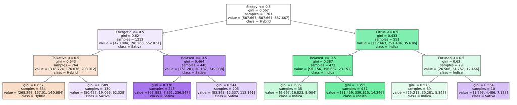

```python
plt.figure(figsize=(50,10))
plot_tree(best_tree_dt_mc, filled=True, feature_names=X.columns, class_names=['Hybrid', 'Indica', 'Sativa'])
plt.show()
```

- The root node splits from a ‘Sleepy’ value of **0.5** and has a gini purity of **0.667** which indicates moderate impurity and this node contains a mixture of classes in the multiclass decision tree classification. There are **1763** samples in this node. There are an average of **587.667** samples evenly distributed among the three classes. ‘Hybrid’ is the dominant class.
- Values lower than **0.5** for ‘Sleepy’ split to the left and splits again at a value of **0.5** for ‘Energetic’. The gini impurity score is **0.62** and this is slightly lower than the root node. There are **1212** samples at this node, and the average samples for each class are **470.004**(Hybrid), **196.263**(Indica), and **552.051**(Sativa). The dominant class at this node is ‘Sativa’.
- Values higher than **0.5** for ‘Sleepy’ split to the right and splits again at a value of **0.5** for ‘Citrus’. The gini impurity score is **0.433** and this is lower than the root node and also the ‘Energetic’ node. There are **551** samples at this node, and the average samples for each class are **117.663**(Hybrid), **391.404**(Indica), **35.616**(Sativa). The dominant class at this node is ‘Indica’.
- The path that yields the least impurity starts from the root node: ‘Sleepy’ –> ‘Citrus’ –> ‘Relaxed’ –> leaf node. The gini impurity score is **0.355**, there are **437** samples, the values of each class are [**81.459, 339.815, 14.246**], and the dominant class is ‘Indica’.

*Q2: Repeat the analyses from Part One for LDA, QDA, and KNN.*

*LDA*

```python
# Training an LDA model and getting a cross-validated F1-Score
lda = LinearDiscriminantAnalysis()
lda_mc_cv_score = cross_val_score(lda, X_train, y_train, cv=5, scoring='f1_macro').mean()
print(f"Cross-validated F1-score for LDA: {lda_mc_cv_score}")
```

```
Cross-validated F1-score for LDA: 0.598070669714101
```

- The cross-validated *F1-Score* for the *LDA* model was **59.81%**. This result was significantly lower than the binary classification models, but higher than the *Decision Tree* multiclass model.

*QDA*

```python
# Tuning a QDA model and getting a cross-validated F1-Score
param_grid_qda_mc = {'reg_param': [0, 0.1, 0.2, 0.3, 0.4, 0.5]}
grid_search_qda_mc = GridSearchCV(QuadraticDiscriminantAnalysis(), param_grid_qda_mc, cv=5, scoring='f1_macro', n_jobs=-1)
grid_search_qda_mc.fit(X_train, y_train)

print(f"Best Parameters for QDA: {grid_search_qda_mc.best_params_}")
print(f"Best Cross-Validated F1-score for QDA: {grid_search_qda_mc.best_score_}")
```

```
Best Parameters for QDA: {'reg_param': 0.3}
Best Cross-Validated F1-score for QDA: 0.5660631803051942
```

*KNN*

```python
from sklearn.neighbors import KNeighborsClassifier

# Tuning a KNN model and getting a cross-validated F1-Score
param_grid_knn_mc = {'n_neighbors': [3, 5, 7, 9, 11, 13], 'weights': ['uniform', 'distance']}
grid_search_knn_mc = GridSearchCV(KNeighborsClassifier(), param_grid_knn_mc, cv=5, scoring='f1_macro', n_jobs=-1)
grid_search_knn_mc.fit(X_train, y_train)

print(f"Best Parameters for KNN: {grid_search_knn_mc.best_params_}")
print(f"Best Cross-Validated F1-score for KNN: {grid_search_knn_mc.best_score_}")
```

```
Best Parameters for KNN: {'n_neighbors': 9, 'weights': 'distance'}
Best Cross-Validated F1-score for KNN: 0.5273718447406373
```

- The best hyperparameters for the *KNN* model were: *n_neighbors*=**9**, *weights*=**distance**.
- The cross-validated *F1-Score* for the multiclass *KNN* model was **52.74%**. This result was significantly lower than the binary classification models, and also lower than the other mutliclass models.

```python
# Evaluating DT's F1-Score on the full model
dt_mc_best = DecisionTreeClassifier()
dt_mc_best.fit(X1, y1)
y_pred_dt_mc = dt_mc_best.predict(X1)
f1_dt_mc = f1_score(y1, y_pred_dt_mc, average='macro')

# Evaluating LDA F1-Score and Conf Matrix on the full model
lda_mc_best = LinearDiscriminantAnalysis()
lda_mc_best.fit(X1, y1)
y_pred_lda_mc = lda_mc_best.predict(X1)
f1_lda_mc = f1_score(y1, y_pred_lda_mc, average='macro')
conf_matrix_lda_mc = confusion_matrix(y1, y_pred_lda_mc)

# Evaluating QDA F1-Score and Conf Matrix on the full model
qda_mc_best = grid_search_qda_mc.best_estimator_
y_pred_qda_mc = qda_mc_best.predict(X1)
f1_qda_mc = f1_score(y1, y_pred_qda_mc, average='macro')
conf_matrix_qda_mc = confusion_matrix(y1, y_pred_qda_mc)

# Evaluating KNN F1-Score and Conf Matrix on the full model
knn_mc_best = grid_search_knn_mc.best_estimator_
y_pred_knn_mc = knn_mc_best.predict(X1)
f1_knn_mc = f1_score(y1, y_pred_knn_mc, average='macro')
conf_matrix_knn_mc = confusion_matrix(y1, y_pred_knn_mc)

# Print results
print(f"LDA Confusion Matrix on Full Dataset:\n{conf_matrix_lda_mc}\n")
print(f"QDA Confusion Matrix on Full Dataset:\n{conf_matrix_qda_mc}\n")
print(f"KNN Confusion Matrix on Full Dataset:\n{conf_matrix_knn_mc}")
```

```
LDA Confusion Matrix on Full Dataset:
[[857 213 142]
 [214 475  10]
 [231  22 187]]

QDA Confusion Matrix on Full Dataset:
[[947 203  62]
 [229 467   3]
 [293  18 129]]

KNN Confusion Matrix on Full Dataset:
[[1108   61   43]
 [  93  603    3]
 [  87    8  345]]
```

*LDA*

*QDA*

*KNN*

- The ‘Hybrid’ class was correctly classified **1108** times and was the highest of the three models, with very few misclassifications. The ‘Sativa’ class was also correctly identified at the highest rate amongst the models, **345**, with the lowest number of misclassifications. It also performed the best in identifying ‘Indica’(**603**) with a very low number of misclassifications.

```python
import numpy as np

# Defining a function to calculate TP, FP, FN, TN
def calculate_metrics(conf_matrix):
    TP = np.diag(conf_matrix)
    FP = conf_matrix.sum(axis=0) - TP
    FN = conf_matrix.sum(axis=1) - TP
    TN = conf_matrix.sum() - (FP + FN + TP)
    return TP.sum(), FP.sum(), FN.sum(), TN.sum()

# Confusion matrices
conf_matrix_dt = np.array([[539, 236, 437], [183, 461, 55], [102, 24, 314]])
conf_matrix_lda = np.array([[852, 216, 144], [217, 470, 12], [221, 21, 198]])
conf_matrix_qda = np.array([[947, 203, 62], [229, 467, 3], [293, 18, 129]])
conf_matrix_knn = np.array([[1108, 61, 43], [93, 603, 3], [87, 8, 345]])

# Calculating metrics for each model
dt_tp, dt_fp, dt_fn, dt_tn = calculate_metrics(conf_matrix_dt)
lda_tp, lda_fp, lda_fn, lda_tn = calculate_metrics(conf_matrix_lda)
qda_tp, qda_fp, qda_fn, qda_tn = calculate_metrics(conf_matrix_qda)
knn_tp, knn_fp, knn_fn, knn_tn = calculate_metrics(conf_matrix_knn)

# F1-Scores for predictions on the training set
f1_train = [grid_search_dt_mc.best_score_, lda_mc_cv_score, grid_search_qda_mc.best_score_, grid_search_knn_mc.best_score_]

# F1-Scores for predictions on the full dataset
f1_scores = [f1_dt_mc, f1_lda_mc, f1_qda_mc, f1_knn_mc]

# Creating dataframe
models_performance = pd.DataFrame({
    'Multiclass Model': ['Decision Tree', 'LDA', 'QDA', 'KNN'],
    'F1-Score (train)': f1_train,
    'F1-Score (full)': f1_scores,
    'TP': [dt_tp, lda_tp, qda_tp, knn_tp],
    'FP': [dt_fp, lda_fp, qda_fp, knn_fp],
    'FN': [dt_fn, lda_fn, qda_fn, knn_fn],
    'TN': [dt_tn, lda_tn, qda_tn, knn_tn]
})

print(models_performance)
```

```
  Multiclass Model  F1-Score (train)  F1-Score (full)    TP    FP    FN    TN
0    Decision Tree          0.563445         0.973536  1314  1037  1037  3665
1              LDA          0.598071         0.612041  1520   831   831  3871
2              QDA          0.566063         0.595596  1543   808   808  3894
3              KNN          0.527372         0.865458  2056   295   295  4407
```

*Q3: Were your metrics better or worse than in Part One? Why? Which categories were most likely to get mixed up, according to the confusion matrices? Why?*

# **Part Three: Multiclass from Binary**

Now use the full dataset, including the Hybrid strains.

```python
# Importing the dataset
weed = pd.read_csv("https://www.dropbox.com/s/s2a1uoiegitupjc/cannabis_full.csv?raw=1")

# Removing the 'Effects' and 'Flavor' variables because they are already dummified
weed = weed.drop(['Effects', 'Flavor'], axis=1)
weed.set_index('Strain', inplace=True)

# Replacing NA values with 0
weed.fillna(0, inplace=True)

# Defining the response and predictor variables
X2 = weed.drop('Type', axis=1)
y2 = weed['Type']

# Splitting the data into training and test sets
X_train, X_test, y_train, y_test = train_test_split(X2, y2, test_size=0.25, random_state=42, stratify=y2)
```

*Q1 Fit and report metrics for OvR versions of the models. That is, for each of the two model types, create three models:*

- Indica vs. Not Indica
- Sativa vs. Not Sativa
- Hybrid vs. Not Hybrid

```python
# Creating variables for each OvR pairing
y_train_indica = [1 if label == 'indica' else 0 for label in y_train]
y_train_sativa = [1 if label == 'sativa' else 0 for label in y_train]
y_train_hybrid = [1 if label == 'hybrid' else 0 for label in y_train]

y_test_indica = [1 if label == 'indica' else 0 for label in y_test]
y_test_sativa = [1 if label == 'sativa' else 0 for label in y_test]
y_test_hybrid = [1 if label == 'hybrid' else 0 for label in y_test]
```

```python
from sklearn.linear_model import LogisticRegression

# Logistic Regression for Indica
logreg_indica = LogisticRegression(max_iter=1000)
logreg_indica.fit(X_train, y_train_indica)

# Logistic Regression for Sativa
logreg_sativa = LogisticRegression(max_iter=1000)
logreg_sativa.fit(X_train, y_train_sativa)

# Logistic Regression for Hybrid
logreg_hybrid = LogisticRegression(max_iter=1000)
logreg_hybrid.fit(X_train, y_train_hybrid)
```

```
LogisticRegression(max_iter=1000)
```

```python
from sklearn.svm import SVC

# SVC for Indica
svc_indica = SVC(probability=True)
svc_indica.fit(X_train, y_train_indica)

# SVC for Sativa
svc_sativa = SVC(probability=True)
svc_sativa.fit(X_train, y_train_sativa)

# SVC for Hybrid
svc_hybrid = SVC(probability=True)
svc_hybrid.fit(X_train, y_train_hybrid)
```

```
SVC(probability=True)
```

```python
# Getting the cross-validated F1-Score for each model
f1_logreg_indica = cross_val_score(logreg_indica, X2, [1 if label == 'indica' else 0 for label in y2], cv=5, scoring='f1')
f1_logreg_sativa = cross_val_score(logreg_sativa, X2, [1 if label == 'sativa' else 0 for label in y2], cv=5, scoring='f1')
f1_logreg_hybrid = cross_val_score(logreg_hybrid, X2, [1 if label == 'hybrid' else 0 for label in y2], cv=5, scoring='f1')
f1_svc_indica = cross_val_score(svc_indica, X2, [1 if label == 'indica' else 0 for label in y2], cv=5, scoring='f1')
f1_svc_sativa = cross_val_score(svc_sativa, X2, [1 if label == 'sativa' else 0 for label in y2], cv=5, scoring='f1')
f1_svc_hybrid = cross_val_score(svc_hybrid, X2, [1 if label == 'hybrid' else 0 for label in y2], cv=5, scoring='f1')

# Calculating the mean F1-Score
avg_f1_logreg_indica = np.mean(f1_logreg_indica)
avg_f1_logreg_sativa = np.mean(f1_logreg_sativa)
avg_f1_logreg_hybrid = np.mean(f1_logreg_hybrid)
avg_f1_svc_indica = np.mean(f1_svc_indica)
avg_f1_svc_sativa = np.mean(f1_svc_sativa)
avg_f1_svc_hybrid = np.mean(f1_svc_hybrid)

# Printing the OvR F1-Scores
print("OvR F1-Scores for Logistic Regression models:")
print("Indica vs. Not Indica:", avg_f1_logreg_indica)
print("Sativa vs. Not Sativa:", avg_f1_logreg_sativa)
print("Hybrid vs. Not Hybrid:", avg_f1_logreg_hybrid)
print("\nOvR F1-Scores for SVC models:")
print("Indica vs. Not Indica:", avg_f1_svc_indica)
print("Sativa vs. Not Sativa:", avg_f1_svc_sativa)
print("Hybrid vs. Not Hybrid:", avg_f1_svc_hybrid)
```

```
OvR F1-Scores for Logistic Regression models:
Indica vs. Not Indica: 0.6389553789238293
Sativa vs. Not Sativa: 0.38416422613967194
Hybrid vs. Not Hybrid: 0.6458676635390506

OvR F1-Scores for SVC models:
Indica vs. Not Indica: 0.6499493729380297
Sativa vs. Not Sativa: 0.0
Hybrid vs. Not Hybrid: 0.6851600064853255
```

*Q2 Which of the six models did the best job distinguishing the target category from the rest? Which did the worst? Does this make intuitive sense?*

- The *SVC* model for ‘Hybrid vs. Not Hybrid’ performed the best with an *F1-Score* of **68.52%**. Surprisingly, the *SVC* model performed the worst at distinguishing between ‘Sativa’ and ‘Not Sativa’ with an *F1-Score* of **0.00%**. This could be due to the *SVC* model only predicting the majority class for ‘Sativa vs. Not Sativa’. The best overall performer was the *Logistic Regression* model.
- Intuitively, distinguishing between ‘Hybrid’ and ‘Not Hybrid’ should have been more difficult, as hybrid strains contain characteristics of both ‘Indica’ and ‘Sativa’. Identifying ‘Indica’ and ‘Sativa’ should have had a higher score.

*Q3 Fit and report metrics for OvO versions of the models. That is, for each of the two model types, create three models:*

- Indica vs. Sativa
- Indica vs. Hybrid
- Hybrid vs. Sativa

```python
# Filtering the dataset for each pair
indica_sativa = weed[(weed['Type'] == 'indica') | (weed['Type'] == 'sativa')]
y_indica_sativa = indica_sativa['Type'].apply(lambda x: 1 if x == 'indica' else 0)

indica_hybrid = weed[(weed['Type'] == 'indica') | (weed['Type'] == 'hybrid')]
y_indica_hybrid = indica_hybrid['Type'].apply(lambda x: 1 if x == 'indica' else 0)

hybrid_sativa = weed[(weed['Type'] == 'hybrid') | (weed['Type'] == 'sativa')]
y_hybrid_sativa = hybrid_sativa['Type'].apply(lambda x: 1 if x == 'hybrid' else 0)
```

```python
# Defining the models
logreg = LogisticRegression(max_iter=1000)
svc = SVC(probability=True)
```

```python
# OvO Logistic Regression models
f1_logreg_indica_sativa = cross_val_score(logreg, indica_sativa.drop('Type', axis=1), y_indica_sativa, cv=5, scoring='f1').mean()
f1_logreg_indica_hybrid = cross_val_score(logreg, indica_hybrid.drop('Type', axis=1), y_indica_hybrid, cv=5, scoring='f1').mean()
f1_logreg_hybrid_sativa = cross_val_score(logreg, hybrid_sativa.drop('Type', axis=1), y_hybrid_sativa, cv=5, scoring='f1').mean()
```

```python
# OvO SVC
f1_svc_indica_sativa = cross_val_score(svc, indica_sativa.drop('Type', axis=1), y_indica_sativa, cv=5, scoring='f1').mean()
f1_svc_indica_hybrid = cross_val_score(svc, indica_hybrid.drop('Type', axis=1), y_indica_hybrid, cv=5, scoring='f1').mean()
f1_svc_hybrid_sativa = cross_val_score(svc, hybrid_sativa.drop('Type', axis=1), y_hybrid_sativa, cv=5, scoring='f1').mean()
```

```python
# Printing the OvO F1-Scores
print("OvO F1-Scores for Logistic Regression models:")
print("Indica vs. Sativa:", f1_logreg_indica_sativa)
print("Indica vs. Hybrid:", f1_logreg_indica_hybrid)
print("Hybrid vs. Sativa:", f1_logreg_hybrid_sativa)
print("\nOvO F1-Scores for SVC models:")
print("Indica vs. Sativa:", f1_svc_indica_sativa)
print("Indica vs. Hybrid:", f1_svc_indica_hybrid)
print("Hybrid vs. Sativa:", f1_svc_hybrid_sativa)
```

```
OvO F1-Scores for Logistic Regression models:
Indica vs. Sativa: 0.8770631479482758
Indica vs. Hybrid: 0.6484622686322487
Hybrid vs. Sativa: 0.8432361427851166

OvO F1-Scores for SVC models:
Indica vs. Sativa: 0.8842036565920905
Indica vs. Hybrid: 0.662830455883179
Hybrid vs. Sativa: 0.8446351682392834
```

*Q4 Which of the six models did the best job distinguishing at differentiating the two groups? Which did the worst? Does this make intuitive sense?*

- The *SVC* model for ‘Indica vs. Sativa’ scored the highest at **88.42%**. The *Logistic Regression* model for ‘Indica vs. Hybrid’ scored the lowest at **64.85%**.
- Both *SVC* and *Logistic Regression* models scored the highest when distinguishing between ‘Indica’ and ‘Sativa’, and this was expected. They are different strains of marijuana, and they both have very different characteristics.
- Both *SVC* and *Logistic Regression* models scored the lowest when distinguishing between ‘Indica’ and ‘Hybrid’, and this was also expected. ‘Hybrid’ strains contain both ‘Indica’ and ‘Sativa’ in their contents, therefore carrying characteristics and traits of both, making it harder to distinguish.
- Both models also distinguished between ‘Sativa’ and ‘Hybrid’ at a high rate and this was unexpected. Because ‘Hybrid’ strains contain both ‘Indica’ and ‘Sativa’ characteristics, the expectation was an *F1-Score* similar to that of ‘Indica vs. Hybrid’.

*Q5 Suppose you had simply input the full data, with three classes, into the LogisticRegression function. Would this have automatically taken an “OvO” approach or an “OvR” approach?*

*What about for SVC?*

*Note: You do not actually have to run code here - you only need to look at sklearn’s documentation to see how these functions handle multiclass input.*

- If the full dataset were inputted, with the three classes, into a *Logistic Regression* model, according to scikit-learn, this would have defaulted to a *OvR* approach.
- In terms of *SVC*, according to scikit-learn, the default behavior would have been to select a *OvO* approach.